# Binary Housing Decision Tree

This notebook will report the findings of creating a decision tree model on a binary version of the Boston housing dataset. For reference:

1. CRIM: per capita crime rate by town
2. ZN: proportion of residential land zoned for lots over 25,000 sq.ft .
3. INDUS: proportion of non retail business acres per town
4. CHAS: Charles River dummy variable (= 1 if tract bounds river; 0 otherwise)
5. NOX: nitric oxides concentration (parts per 10 million)
6. RM: average number of rooms per dwelling
7. AGE: proportion of owner occupied units built prior to 1940
8. DIS: weighted distances to five Boston employment centers
9. RAD: index of accessibility to radial highways
10. TAX: full value property tax rate per 10,000
11. PTRATIO: pupil teacher ratio by town
12. B: 1000(Bk 0.63)^2 where Bk is the proportion of blacks by town
13. LSTAT: percent lower status of the population
14. MEDV: Median value of owner occupied homes in 1000's

Note that in this dataset, an instance has a median house value of 1 if the median house value is greater than 230k and 0 if it is not.

First we must load the dataset.

```r
housing<-read.table("housing.header.binary.txt", header=TRUE, sep=",")
colnames(housing)<-c("Crim", "Zn", "Indus", "Chas", "Nox", "Rm", "Age", "Dis", "Rad", "Tax", "Ptratio", "B", "Lstat", "Medv")
summary(housing)
```

```
      Crim                Zn             Indus            Chas
 Min.   : 0.00632   Min.   :  0.00   Min.   : 0.46   Min.   :0.00000
 1st Qu.: 0.08204   1st Qu.:  0.00   1st Qu.: 5.19   1st Qu.:0.00000
 Median : 0.25651   Median :  0.00   Median : 9.69   Median :0.00000
 Mean   : 3.61352   Mean   : 11.36   Mean   :11.14   Mean   :0.06917
 3rd Qu.: 3.67708   3rd Qu.: 12.50   3rd Qu.:18.10   3rd Qu.:0.00000
 Max.   :88.97620   Max.   :100.00   Max.   :27.74   Max.   :1.00000
      Nox               Rm             Age              Dis
 Min.   :0.3850   Min.   :3.561   Min.   :  2.90   Min.   : 1.130
 1st Qu.:0.4490   1st Qu.:5.886   1st Qu.: 45.02   1st Qu.: 2.100
 Median :0.5380   Median :6.208   Median : 77.50   Median : 3.207
 Mean   :0.5547   Mean   :6.285   Mean   : 68.57   Mean   : 3.795
 3rd Qu.:0.6240   3rd Qu.:6.623   3rd Qu.: 94.08   3rd Qu.: 5.188
 Max.   :0.8710   Max.   :8.780   Max.   :100.00   Max.   :12.127
      Rad              Tax           Ptratio            B
 Min.   : 1.000   Min.   :187.0   Min.   :12.60   Min.   :  0.32
 1st Qu.: 4.000   1st Qu.:279.0   1st Qu.:17.40   1st Qu.:375.38
 Median : 5.000   Median :330.0   Median :19.05   Median :391.44
 Mean   : 9.549   Mean   :408.2   Mean   :18.46   Mean   :356.67
 3rd Qu.:24.000   3rd Qu.:666.0   3rd Qu.:20.20   3rd Qu.:396.23
 Max.   :24.000   Max.   :711.0   Max.   :22.00   Max.   :396.90
     Lstat            Medv
 Min.   : 1.73   Min.   :0.0000
 1st Qu.: 6.95   1st Qu.:0.0000
 Median :11.36   Median :0.0000
 Mean   :12.65   Mean   :0.3834
 3rd Qu.:16.95   3rd Qu.:1.0000
 Max.   :37.97   Max.   :1.0000
```

We will use the Crim index and number of rooms in a building as independent variables to train an RPART decision tree that predicts whether the median house value is 0 or 1.

```r
library(rpart)
fit<-rpart(Medv~Crim+Rm, method="class", data=housing)
summary(fit)
```

```
Call:
rpart(formula = Medv ~ Crim + Rm, data = housing, method = "class")
  n= 506

          CP nsplit rel error    xerror       xstd
1 0.51546392      0 1.0000000 1.0000000 0.05637690
2 0.05670103      1 0.4845361 0.5206186 0.04634589
3 0.01546392      2 0.4278351 0.4639175 0.04433951
4 0.01374570      5 0.3814433 0.5257732 0.04651722
5 0.01030928      8 0.3402062 0.5103093 0.04599788
6 0.01000000     11 0.3041237 0.5154639 0.04617278

Variable importance
  Rm Crim
  69   31

Node number 1: 506 observations,    complexity param=0.5154639
  predicted class=0  expected loss=0.3833992  P(node) =1
    class counts:   312   194
   probabilities: 0.617 0.383
  left son=2 (362 obs) right son=3 (144 obs)
  Primary splits:
      Rm   < 6.5455   to the left,  improve=86.60421, (0 missing)
      Crim < 0.66771  to the right, improve=30.94264, (0 missing)
  Surrogate splits:
      Crim < 0.0273   to the right, agree=0.739, adj=0.083, (0 split)

Node number 2: 362 observations,    complexity param=0.01546392
  predicted class=0  expected loss=0.198895  P(node) =0.715415
    class counts:   290    72
   probabilities: 0.801 0.199
  left son=4 (227 obs) right son=5 (135 obs)
  Primary splits:
      Rm   < 6.143    to the left,  improve=10.567340, (0 missing)
      Crim < 0.60872  to the right, improve= 5.439062, (0 missing)
  Surrogate splits:
      Crim < 0.042975 to the right, agree=0.652, adj=0.067, (0 split)

Node number 3: 144 observations,    complexity param=0.05670103
  predicted class=1  expected loss=0.1527778  P(node) =0.284585
```

[output cut: 133 more lines]

```

Node number 179: 10 observations
  predicted class=1  expected loss=0.2  P(node) =0.01976285
    class counts:     2     8
   probabilities: 0.200 0.800

Node number 186: 9 observations
  predicted class=0  expected loss=0.3333333  P(node) =0.01778656
    class counts:     6     3
   probabilities: 0.667 0.333

Node number 187: 15 observations
  predicted class=1  expected loss=0.2  P(node) =0.02964427
    class counts:     3    12
   probabilities: 0.200 0.800
```

Next we visualize the tree:

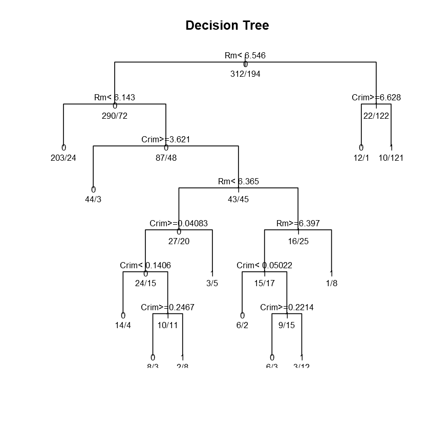

```r
plot(fit, uniform=TRUE, main="Decision Tree")
text(fit, use.n=TRUE, all=TRUE, cex=.8)
```

The above decision tree looks at each instance and performs the following splits:

Root node-Is Rm<6.546?

312 instances were split as negatives, and 194 were split as positives.

Traversing the left subtree, we ask:

Is Rm < 6.143?

290 instances were split as negatives, and 72 were split as positives.

Continuing down the left subtree, we have a class label of 0 in response to an answer of 0 to the above question. Here we have 203 instances that were true negatives and 24 that were not.

Traversing the right subtree from the above node, we ask:

Is Crim>=3.621?

87 instances were split as negatives, and 48 were split as positives.

Moving left from here, we have a class label of 0 in response to an answer of 0 to the above question. Here we have 44 instances that were true negatives and 3 that were not.

43 instances were split as negatives, and 45 were split as positives.

27 instances were split as negatives, and 20 were split as positives.

Moving right from here, we have a class label of 1 in response to an answer of 1 to the above question. Here we have 5 instances that were true positives and 3 that were not.

The above described process can be used for each decision node to eventually reach a leaf node.

Now we will use all variables to train an RPART decision tree that predicts whether the median house value is 0 or 1. We will use 80% of the data to fit the tree, and 20% of the data to test the effectiveness of the decision tree model.

```r
set.seed(1)
train<-sample(1:nrow(housing), 0.8*nrow(housing))
train.set<-housing[train,]
test.set<-housing[-train,]
housing.tree<-rpart(Medv~Crim+Zn+Indus+Chas+Nox+Rm+Age+Dis+Rad+Tax+Ptratio+B+Lstat, data=housing[train,], method="class")
summary(housing.tree)
```

```
Call:
rpart(formula = Medv ~ Crim + Zn + Indus + Chas + Nox + Rm +
    Age + Dis + Rad + Tax + Ptratio + B + Lstat, data = housing[train,
    ], method = "class")
  n= 404

          CP nsplit rel error    xerror       xstd
1 0.65644172      0 1.0000000 1.0000000 0.06049563
2 0.06134969      1 0.3435583 0.4233129 0.04640542
3 0.03067485      2 0.2822086 0.4110429 0.04586423
4 0.01000000      3 0.2515337 0.3742331 0.04415030

Variable importance
Lstat    Rm Indus   Nox  Crim   Age   Dis     B
   25    17    16    15    13    13     1     1

Node number 1: 404 observations,    complexity param=0.6564417
  predicted class=0  expected loss=0.4034653  P(node) =1
    class counts:   241   163
   probabilities: 0.597 0.403
  left son=2 (227 obs) right son=3 (177 obs)
  Primary splits:
      Lstat   < 10.14    to the right, improve=100.19760, (0 missing)
      Rm      < 6.5455   to the left,  improve= 72.03598, (0 missing)
      Indus   < 8.005    to the right, improve= 51.39322, (0 missing)
      Ptratio < 19.9     to the right, improve= 45.67274, (0 missing)
      Nox     < 0.5125   to the right, improve= 45.53887, (0 missing)
  Surrogate splits:
      Indus < 7.625    to the right, agree=0.829, adj=0.610, (0 split)
      Nox   < 0.519    to the right, agree=0.809, adj=0.565, (0 split)
      Rm    < 6.476    to the left,  agree=0.790, adj=0.520, (0 split)
      Age   < 52.05    to the right, agree=0.775, adj=0.486, (0 split)
      Crim  < 0.09278  to the right, agree=0.767, adj=0.469, (0 split)

Node number 2: 227 observations
  predicted class=0  expected loss=0.09251101  P(node) =0.5618812
    class counts:   206    21
   probabilities: 0.907 0.093

Node number 3: 177 observations,    complexity param=0.06134969
```

[output cut: 34 more lines]

```

Node number 7: 147 observations
  predicted class=1  expected loss=0.1020408  P(node) =0.3638614
    class counts:    15   132
   probabilities: 0.102 0.898

Node number 12: 19 observations
  predicted class=0  expected loss=0.1052632  P(node) =0.0470297
    class counts:    17     2
   probabilities: 0.895 0.105

Node number 13: 11 observations
  predicted class=1  expected loss=0.2727273  P(node) =0.02722772
    class counts:     3     8
   probabilities: 0.273 0.727
```

```r
housing.pred<-predict(housing.tree, housing[-train,], type="class")
table(housing[-train,]$Medv, housing.pred)
```

```
   housing.pred
     0  1
  0 62  9
  1  7 24
```

From this, we have that:

True Positive Rate=24/(24+7)=24/31=0.7742

False Positive Rate=9/(9+62)=9/71=0.1268

Accuracy: (62+24)/(62+24+9+7)=86/102=84.31%

Next we show the ROC curve of the classifier which plots true positve rate as a function of false positve rate:

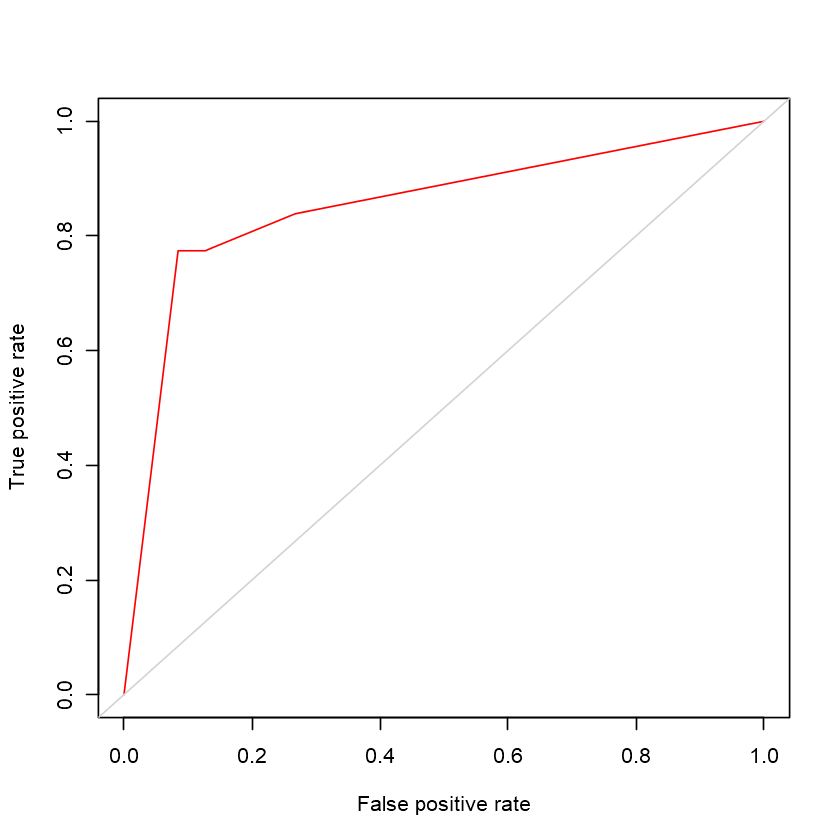

```r
housing.prob<-predict(housing.tree,housing[-train, ], type="prob")
housing.prob.label<-cbind(housing.prob[, 2], housing[-train,]$Medv)
library(ROCR)

pred<-prediction(housing.prob.label[, 1], housing.prob.label[, 2])
perf<-performance(pred, "tpr", "fpr")
plot(perf, col="red")
abline(0,1, col="lightgray")
```

Next we show the AUC value:

```r
auc<-performance(pred, "auc")
auc
auc@y.values[[1]]
```

```
An object of class "performance"
Slot "x.name":
[1] "None"

Slot "y.name":
[1] "Area under the ROC curve"

Slot "alpha.name":
[1] "none"

Slot "x.values":
list()

Slot "y.values":
[[1]]
[1] 0.8523398


Slot "alpha.values":
list()
```

0.852339845524761

Next we can create a new instance on which to perform a prediction:

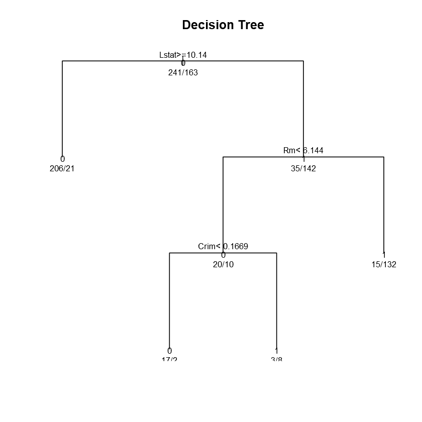

```r
ninst<-c(0.03, 13, 3.5, 0.3, 0.58, 4.1, 68, 4.98, 3, 225, 17, 396, 7.56)
names(ninst)<-c("Crim", "Zn", "Indus", "Chas", "Nox", "Rm", "Age", "Dis", "Rad", "Tax", "Ptratio", "B", "Lstat")
ninst.frame<-data.frame(ninst)
plot(housing.tree, uniform=TRUE, main="Decision Tree")
text(housing.tree, use.n=TRUE, all=TRUE, cex=.8)
```

Using this decison tree on the new instance, we get a class label of 0.